# collateral

[figure not shown]

[figure not shown]

R is great at automating a data analysis over many groups in a dataset, but errors, warnings and other side effects can stop it in its tracks. There’s nothing worse than returning after an hour (or a day!) and discovering that 90% of your data wasn’t analysed because one group threw an error.

With `collateral`, you can capture side effects like errors to prevent them from stopping execution. Once your analysis is done, you can see a tidy view of the groups that failed, the ones that returned a results, and the ones that threw warnings, messages or other output as they ran.

You can even filter or summarise a data frame based on these side effects to automatically continue analysis without failed groups (or perhaps to show a report of the failed ones).

For example, this screenshot shows a data frame that’s been nested using groups of the `cyl` column. The `qlog` column shows the results of an operation that’s returned results for all three groups but also printed a warning for one of them:

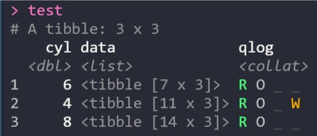

If you’re not familiar with `purrr` or haven’t used a list-column workflow in R before, the [`collateral` vignette](https://collateral.jamesgoldie.dev/articles/collateral.html) shows you how it works, the benefits for your analysis and how `collateral` simplifies the process of handling complex mapped operations.

If you’re already familiar with `purrr`, the [tl;dr](https://en.wikipedia.org/wiki/Wikipedia:Too_long;_didn%27t_read) is that [`collateral::map_safely()` and `collateral::map_quietly()` (and their `map2` and `pmap` variants)](https://collateral.jamesgoldie.dev/reference/collateral_mappers.html) will automatically wrap your supplied function in `safely()` or `quietly()` (or both: `peacefully()`) and will provide enhanced printed output and tibble displays. You can then use the [`has_*()`](https://collateral.jamesgoldie.dev/reference/has.html) and [`tally_*()`](https://collateral.jamesgoldie.dev/reference/tally.html) functions to filter or summarise the returned tibbles or lists.

## Installation

You can install the released version of collateral from [CRAN](https://CRAN.R-project.org) with:

```r
install.packages("collateral")
```

And the development version from [GitHub](https://github.com/) with:

```r
# install.packages("devtools")
devtools::install_github("jimjam-slam/collateral")
```

## Example

This example uses the famous `mtcars` dataset—but first, we’re going to sabotage a few of the rows by making them negative. The `log` function produces `NaN` with a warning when you give it a negative number.

It’d be easy to miss this in a non-interactive script if you didn’t explicitly test for the presence of `NaN`! Thankfully, with collateral, you can see which operations threw errors, which threw warnings, and which produced output:

```r
library(tibble)
library(dplyr)
```

```r
library(tidyr)
library(collateral)

test <-
  # tidy up and trim down for the example
  mtcars %>%
  rownames_to_column(var = "car") %>%
  as_tibble() %>%
  select(car, cyl, disp, wt) %>%
  # spike some rows in cyl == 4 to make them fail
  mutate(wt = dplyr::case_when(
    wt < 2 ~ -wt,
    TRUE ~ wt)) %>%
  # nest and do some operations peacefully
  nest(data = -cyl) %>%
  mutate(qlog = map_peacefully(data, ~ log(.$wt)))

# look at the results
test
```

```
#> # A tibble: 3 × 3
#>     cyl data              qlog
#>   <dbl> <list>            <collat>
#> 1     6 <tibble [7 × 3]>  R _ _ _ _
#> 2     4 <tibble [11 × 3]> R _ _ W _
#> 3     8 <tibble [14 × 3]> R _ _ _ _
```

```r
test %>% mutate(qlog_warning = map_chr(qlog, "warnings", .null = NA))
```

```
#> # A tibble: 3 × 4
#>     cyl data              qlog      qlog_warning
#>   <dbl> <list>            <collat>  <chr>
#> 1     6 <tibble [7 × 3]>  R _ _ _ _ <NA>
#> 2     4 <tibble [11 × 3]> R _ _ W _ NaNs produced
#> 3     8 <tibble [14 × 3]> R _ _ _ _ <NA>
```

… filter on them…

```r
test %>% filter(!has_warnings(qlog))
```

```
#> # A tibble: 2 × 3
#>     cyl data              qlog
#>   <dbl> <list>            <collat>
#> 1     6 <tibble [7 × 3]>  R _ _ _ _
#> 2     8 <tibble [14 × 3]> R _ _ _ _
```

… or get a summary of them, for either interactive or non-interactive purposes:

```r
summary(test$qlog)
```

```
#> 3 elements in total.
#> 3 elements returned results,
#> 3 elements delivered output,
#> 0 elements delivered messages,
#> 1 element delivered warnings, and
#> 0 elements threw an error.
```

## Other features

The collateral package is now fully integrated with the `furrr` package, so you can safely and quietly iterate operations across CPUs cores or remote nodes. All collateral mappers have `future_*`-prefixed variants for this purpose.

## Support

If you have a problem with `collateral`, please don’t hesitate to [file an issue](https://github.com/jimjam-slam/collateral/issues/new) or [contact me](https://twitter.com/jimjam_slam/)!